# Clase 3. Visualización de datos

#### **1. Cargar paquetes.**

Recordemos que los paquetes solo se instalan una vez, pero deben cargarse cada vez que abrimos una nueva sesión de RStudio.

```r
# Instalar paquetes nuevos (solo la primera vez)
install.packages("wesanderson")
install.packages("ggbeeswarm")
install.packages("ggdist")
```

```r
# Cargar paquetes cada vez que abrimos una sesión nueva
library(tidyverse)
library(readxl)
library(wesanderson) # Paletas de colores inspiradas en Wes Anderson
library(ggbeeswarm)  # Para graficar puntos individuales
library(ggdist)      # Para gráficos de distribución tipo "halfeye"
```

#### **2. Importar datos.**

Trabajaremos nuevamente con la base de datos `Tabla_camelida.xlsx`. Puedes encontrarla en el repositorio del curso o descargarla directamente haciendo click [aquí](https://github.com/Arqueologia-Cuantitativa-UC/ANT305Q-2026/blob/main/Clases/Clase2/Tabla%20camelida.xlsx?raw=true).

```r
camelidos <- read_excel("~/Desktop/work/0_Cuantitativa_2026/ANT305Q-2026/Clases/Clase2/Tabla camelida.xlsx")
camelidos
```

```
## # A tibble: 33 × 3
##    Taxon Largo Ancho
##    <chr> <dbl> <dbl>
##  1 LLAMA  80.3  35.4
##  2 LLAMA  71.6  21.2
##  3 LLAMA  70.9  22.0
##  4 LLAMA  70.6  22.3
##  5 LLAMA  69.1  22.7
##  6 LLAMA  68.7  20.8
##  7 LLAMA  67.8  20
##  8 LLAMA  66.6  21
##  9 LLAMA  65.9  20.3
## 10 LLAMA  65.8  21.2
## # ℹ 23 more rows
```

#### **3. Personalización de histogramas**

##### **3.1. Colorear por grupo con `fill` y `color`.**

Podemos indicarle a `ggplot2` que asigne colores automáticamente según una variable categórica (como `Taxon`). Para esto, incluimos `fill = Taxon`. Luego, si queremos elegir nuestros propios colores, agregamos `scale_fill_manual()`.

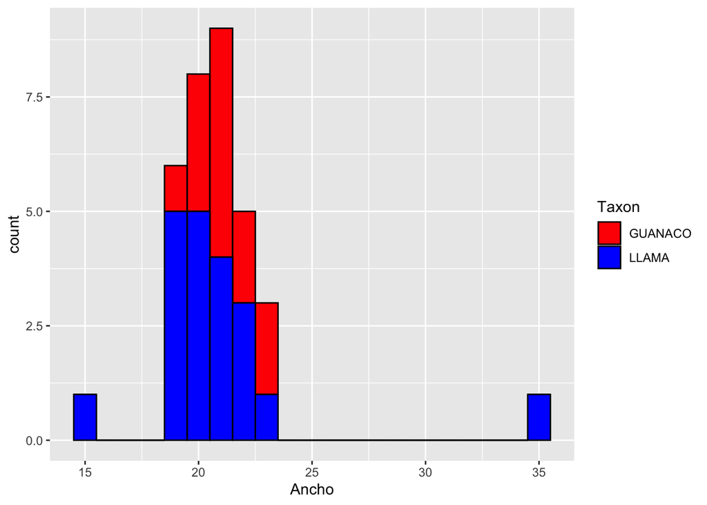

```r
ggplot(data = camelidos, aes(x = Ancho, fill = Taxon)) +
  geom_histogram(binwidth = 1, color="black") +
  scale_fill_manual(values = c("red", "blue"))
```

##### **3.2. Controlar los valores de los ejes con `scale_x_continuous()` y `scale_y_continuous()`.**

Podemos definir exactamente qué números aparecen en los ejes usando la función `seq(inicio, fin, cada cuantos números)`. Por ejemplo, `seq(0, 10, 2)` generará la secuencia 0, 2, 4, 6, 8, 10.

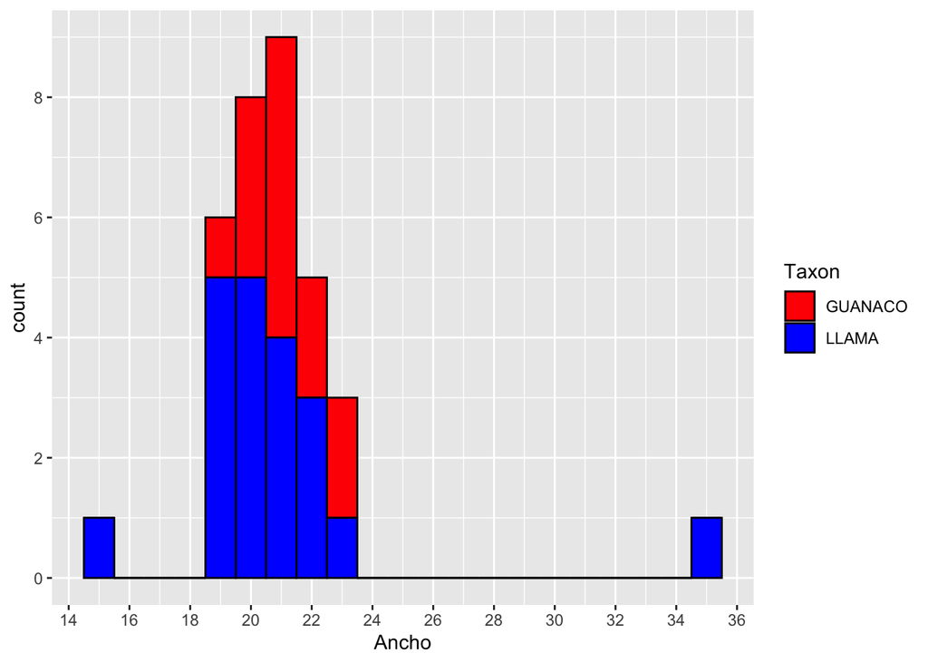

```r
ggplot(data = camelidos, aes(x = Ancho, fill = Taxon, color = Taxon)) +
  geom_histogram(binwidth = 1, color = "black") +
  scale_fill_manual(values = c("red", "blue")) +
  scale_y_continuous(breaks = seq(0, 10, 2)) +
  scale_x_continuous(breaks = seq(14, 36, 2))
```

##### **3.3. Editar etiquetas de ejes y agregar título con `labs()`.**

La función `labs()` nos permite cambiar los nombres que aparecen en los ejes y agregar un título al gráfico. Es buena práctica incluir las unidades de medida en las etiquetas de los ejes.

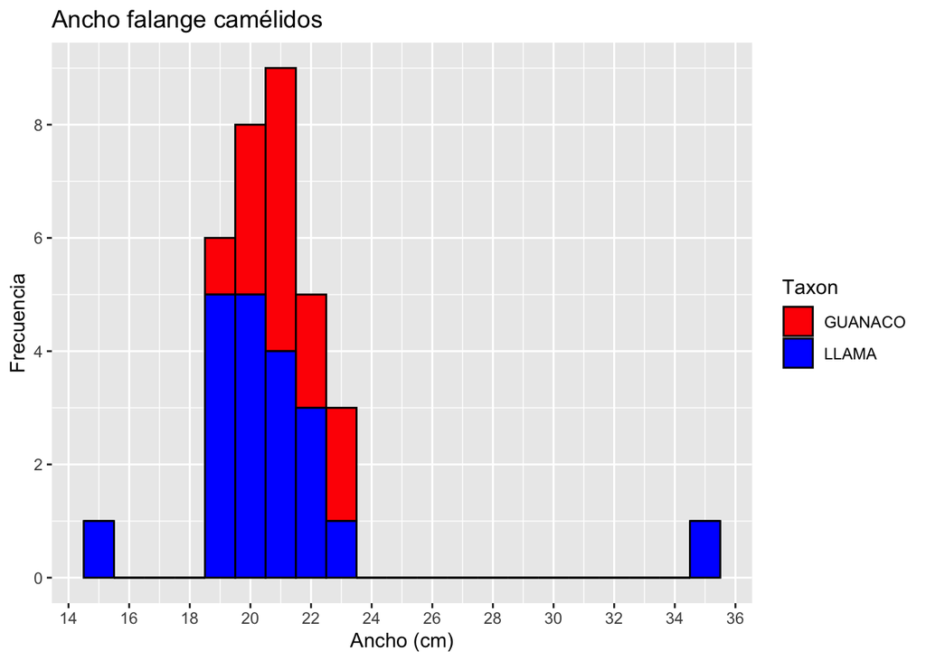

```r
ggplot(data= camelidos, aes(x = Ancho, fill = Taxon, color = Taxon)) +
  geom_histogram(binwidth = 1, color = "black") +
  scale_fill_manual(values = c("red", "blue")) +
  scale_y_continuous(breaks = seq(0, 10, 2)) +
  scale_x_continuous(breaks = seq(14, 36, 2)) +
  labs(x = "Ancho (cm)", y = "Frecuencia", title = "Ancho falange camélidos")
```

##### **3.4. Cambiar el fondo del gráfico con `theme_*()`.**

`ggplot2` incluye varios temas predefinidos que cambian la apariencia general del gráfico, especialmente el color del fondo. Algunos ejemplos son: `theme_bw()`, `theme_classic()`, `theme_dark()`, `theme_gray()`, `theme_light()`, `theme_void()`.

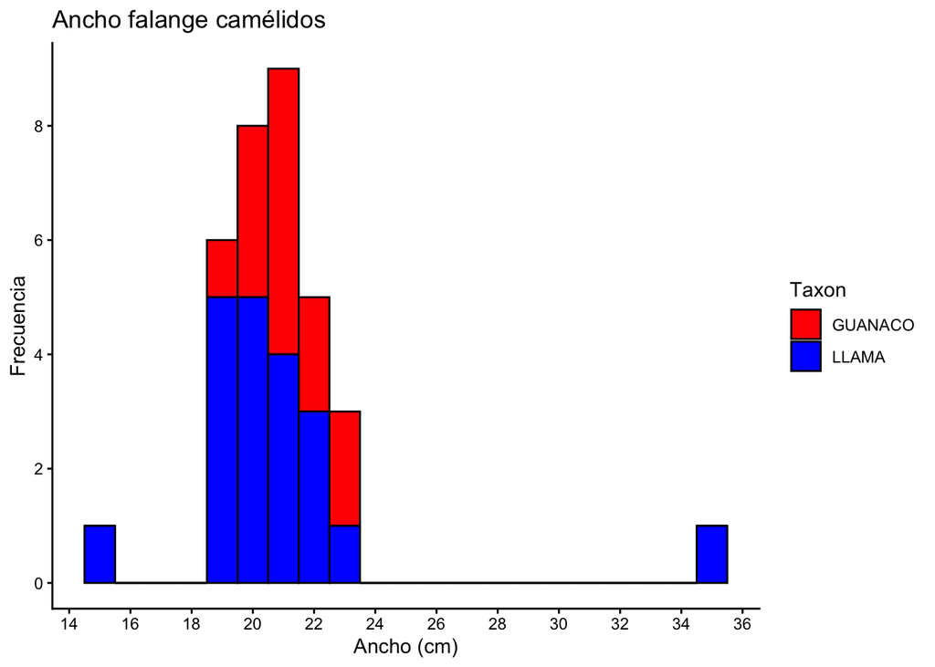

```r
ggplot(data = camelidos, aes(x = Ancho, fill = Taxon, color = Taxon)) +
  geom_histogram(binwidth = 1, color = "black") +
  scale_fill_manual(values = c("red", "blue")) +
  scale_y_continuous(breaks = seq(0, 10, 2)) +
  scale_x_continuous(breaks = seq(14, 36, 2)) +
  labs(x = "Ancho (cm)", y = "Frecuencia", title = "Ancho falange camélidos") +
  theme_classic()
```

#### **4. Boxplots (Gráficos de cajas y bigotes).**

Los boxplots son una forma muy útil de visualizar la distribución de una variable numérica para distintos grupos. Muestran la mediana, los cuartiles y los valores atípicos. Para crearlos usamos la función `geom_boxplot()`.

A diferencia del histograma, aquí debemos especificar tanto el eje **x** (variable categórica, como `Taxon`) como el eje **y** (variable numérica, como `Ancho` o `Largo`) dentro de `aes()`.

##### **4.1. Boxplot básico.**

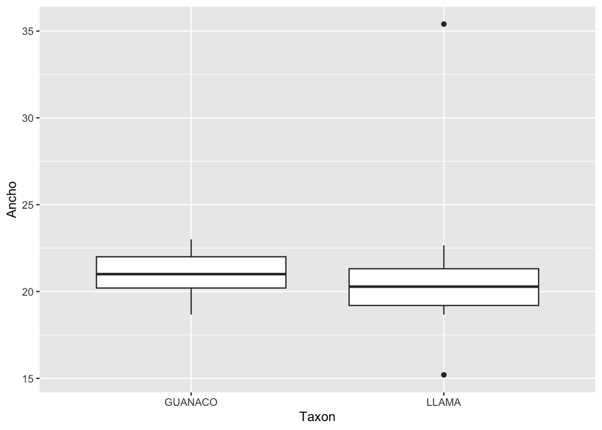

```r
ggplot(data = camelidos, aes(x = Taxon, y = Ancho)) +
  geom_boxplot()
```

##### **4.2. Rotar el boxplot con `coord_flip()`.**

Si preferimos verlo en forma horizontal, podemos agregar la función `coord_flip()`.

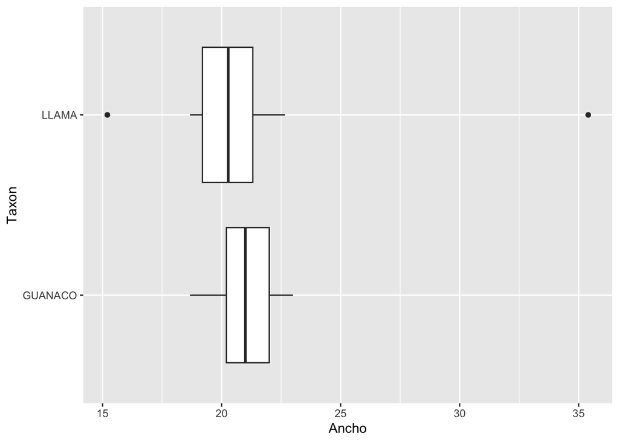

```r
ggplot(data = camelidos, aes(x = Taxon, y = Ancho)) +
  geom_boxplot() +
  coord_flip()
```

O bien intercambiando los ejes

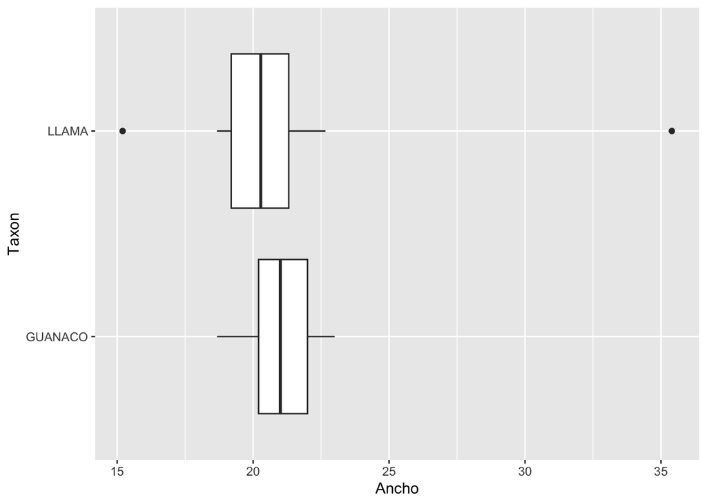

```r
ggplot(data = camelidos, aes(x = Ancho, y = Taxon)) +
  geom_boxplot()
```

##### **4.3. Personalizar colores con `scale_fill_manual()`.**

Al igual que en el histograma, podemos asignar colores por grupo. Para esto incluimos `fill = Taxon` en `aes()` y luego definimos los colores con `scale_fill_manual()`.

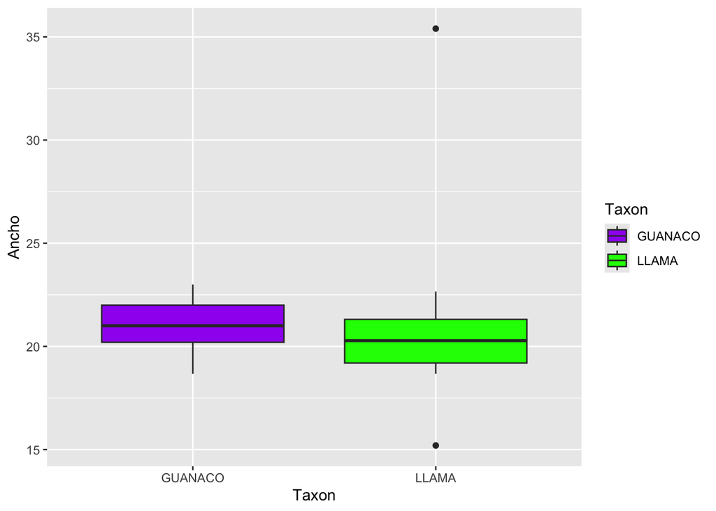

```r
ggplot(data = camelidos, aes(x = Taxon, y = Ancho, fill = Taxon)) +
  geom_boxplot() +
  scale_fill_manual(values = c("purple", "green"))
```

##### **4.4. Usar paletas predefinidas con `scale_fill_brewer()`.**

En lugar de elegir los colores manualmente, podemos usar paletas de colores prediseñadas disponibles en `ggplot2` a través de `scale_fill_brewer()`. Puedes explorar las opciones disponibles en [colorbrewer2.org](https://colorbrewer2.org/).

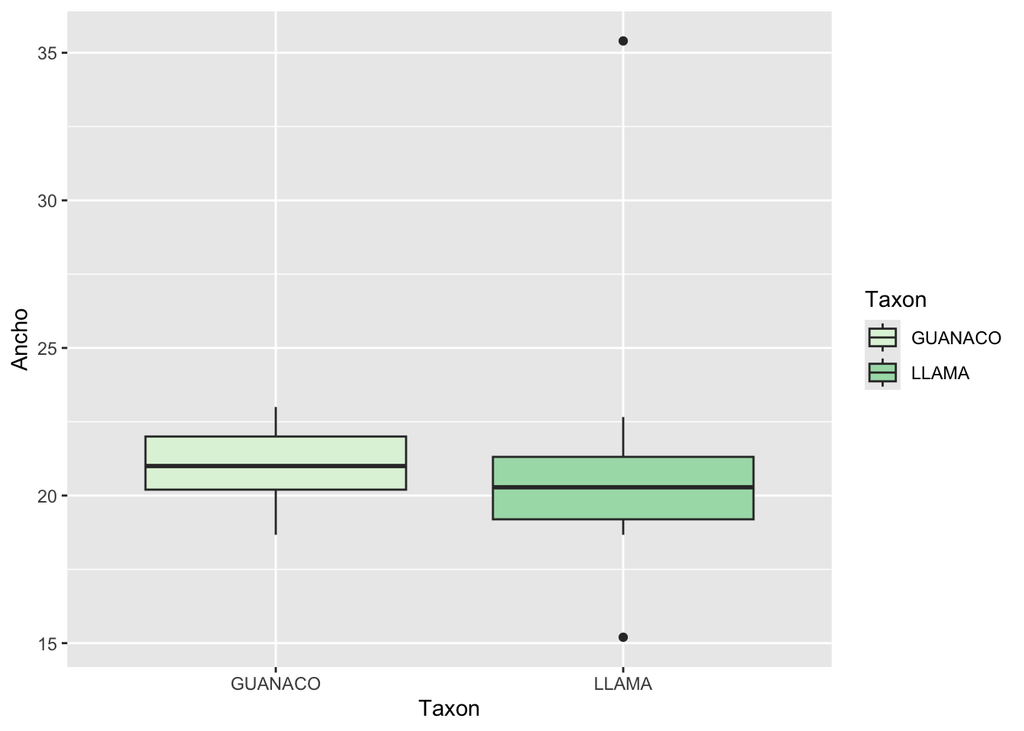

```r
ggplot(data = camelidos, aes(x = Taxon, y = Ancho, fill = Taxon)) +
  geom_boxplot() +
  scale_fill_brewer(palette = "GnBu")
```

##### **4.5. Boxplot completamente personalizado.**

Combinamos todo lo aprendido: colores, escala del eje, etiquetas y tema de fondo.

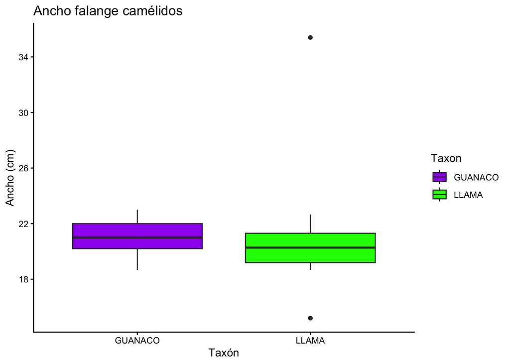

```r
ggplot(data = camelidos, aes(x = Taxon, y = Ancho, fill = Taxon)) +
  geom_boxplot() +
  scale_fill_manual(values = c("purple", "green")) +
  scale_y_continuous(breaks = seq(14, 36, 4)) +
  labs(x = "Taxón", y = "Ancho (cm)", title = "Ancho falange camélidos") +
  theme_classic()
```

##### **4.6. Boxplot para la variable `Largo`.**

Primero revisamos el rango de valores con `summary()` para saber qué secuencia usar en el eje y.

```r
summary(camelidos$Largo)
```

```
##    Min. 1st Qu.  Median    Mean 3rd Qu.    Max.
##   40.20   62.90   66.43   66.24   70.90   80.30
```

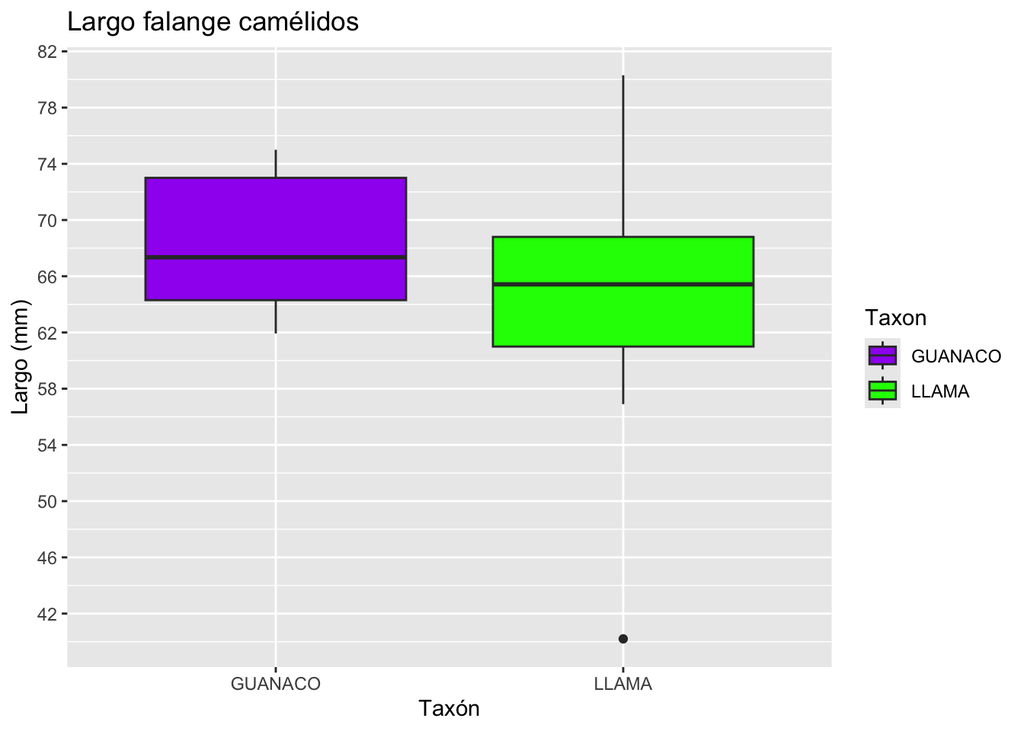

```r
ggplot(data = camelidos, aes(x = Taxon, y = Largo, fill = Taxon)) +
  geom_boxplot() +
  scale_fill_manual(values = c("purple", "green")) +
  scale_y_continuous(breaks = seq(38, 82, 4)) +
  labs(x = "Taxón", y = "Largo (mm)", title = "Largo falange camélidos") +
  theme_gray()
```

#### **5. Paletas de colores: paquete `wesanderson`.**

El paquete `wesanderson` ofrece paletas de colores inspiradas en las películas del director Wes Anderson. Podemos ver todas las paletas disponibles con la función `names()`.

```r
names(wesanderson::wes_palettes)
```

```
##  [1] "BottleRocket1"     "BottleRocket2"     "Rushmore1"
##  [4] "Rushmore"          "Royal1"            "Royal2"
##  [7] "Zissou1"           "Zissou1Continuous" "Darjeeling1"
## [10] "Darjeeling2"       "Chevalier1"        "FantasticFox1"
## [13] "Moonrise1"         "Moonrise2"         "Moonrise3"
## [16] "Cavalcanti1"       "GrandBudapest1"    "GrandBudapest2"
## [19] "IsleofDogs1"       "IsleofDogs2"       "FrenchDispatch"
## [22] "AsteroidCity1"     "AsteroidCity2"     "AsteroidCity3"
```

Para usar una paleta de este paquete dentro de `ggplot2`, reemplazamos los colores en `scale_fill_manual()` por la función `wes_palette()`, indicando el número de colores que necesitamos (`n=2`) y el nombre de la paleta.

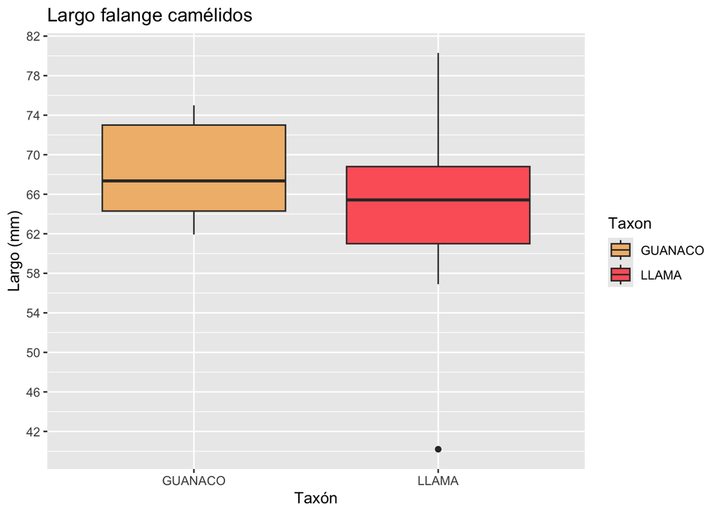

```r
ggplot(data = camelidos, aes(x = Taxon, y = Largo, fill = Taxon)) +
  geom_boxplot() +
  scale_y_continuous(breaks = seq(38, 90, 4)) +
  labs(x = "Taxón", y = "Largo (mm)", title = "Largo falange camélidos") +
  theme_gray() +
  scale_fill_manual(values = wes_palette(n = 2, "GrandBudapest1"))
```

Recursos útiles para explorar más paletas y opciones de color en R:

- [R Color Palettes (Emil Hvitfeldt)](https://github.com/EmilHvitfeldt/r-color-palettes)
- Colores en ggplot2 (cookbook-r.com)
- [Tabla de colores de R (pdf)](http://www.stat.columbia.edu/~tzheng/files/Rcolor.pdf)
- [Datanovia: mejores trucos de colores en ggplot2](https://www.datanovia.com/en/blog/ggplot-colors-best-tricks-you-will-love/)

#### **6. Raincloud Plots.**

Los **raincloud plots** son una forma más completa de visualizar distribuciones de datos. Combinan tres elementos en un solo gráfico:

1. **Media-nube** (`stat_halfeye`): muestra la distribución de probabilidad estimada.
2. **Boxplot** (`geom_boxplot`): muestra la mediana y los cuartiles.
3. **Puntos individuales** (`geom_beeswarm`): muestra cada observación de forma individual.

Esta combinación evita ocultar información importante que los boxplots tradicionales pueden omitir.

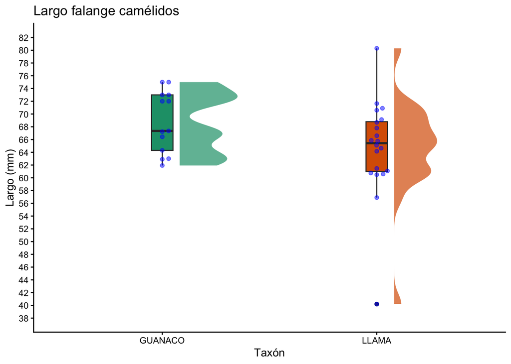

```r
ggplot(data = camelidos, aes(x = Taxon, y = Largo, fill = Taxon)) +
  # Capa 1: distribución tipo "nube"
  ggdist::stat_halfeye(
    adjust = 0.5, width = 0.3, .width = 0,
    justification = -0.3, point_colour = NA, alpha = 0.7
  ) +
  # Capa 2: boxplot compacto
  geom_boxplot(width = 0.1) +
  # Capa 3: puntos individuales ("lluvia")
  geom_beeswarm(alpha = 0.5, color = "blue", cex = 1.5) +
  scale_fill_brewer(palette = "Dark2") +
  scale_y_continuous(limits = c(38, 82), breaks = seq(38, 82, 2)) +
  labs(x = "Taxón", y = "Largo (mm)", title = "Largo falange camélidos") +
  theme_classic()+
  theme(legend.position = "none")
```

Recursos adicionales sobre visualización en R:

- [Cookbook for R - Gráficos](http://www.cookbook-r.com/Graphs/)
- [ggplot2 boxplots (STHDA)](http://www.sthda.com/english/wiki/ggplot2-box-plot-quick-start-guide-r-software-and-data-visualization)
- [Tutorial completo de ggplot2 (Cédric Scherer)](https://www.cedricscherer.com/2019/08/05/a-ggplot2-tutorial-for-beautiful-plotting-in-r/)
- [Top 50 visualizaciones en ggplot2](http://r-statistics.co/Top50-Ggplot2-Visualizations-MasterList-R-Code.html)
- [R Gallery](https://r-graph-gallery.com)

#### **7. Trabajo en Clases 3.**

1. Realice un histograma de los valores de d15N para el Período Formativo. Dentro del histograma incluya color de borde, color de relleno, fondo del gráfico, nombres de etiqueta de ejes x e y, agregue título y ajuste los valores de los ejes x e y.
2. ¿Qué puede interpretar a partir del histograma?
3. Realice un histograma de los valores de d15N para el Período Intermedio Tardío. Dentro del histograma incluya color de borde, color de relleno, fondo del gráfico, nombres de etiqueta de ejes x e y, agregue título y ajuste los valores de los ejes x e y.
4. ¿Qué puede interpretar a partir del histograma?¿Hay diferencias en relación al Período Formativo?
5. Realice un boxplot comparando todos los períodos de la tabla de Plantas. Incluya color de relleno, fondo del gráfico, nombres de etiqueta de ejes x e y, agregue título y ajuste los valores del eje y. Describa el boxplot incluyendo lo que ocurre en cada período en relación a los valores de nitrógeno. Calcule y mencione la mediana e IQR para cada período.
6. ¿Qué ocurre con los valores de d15N a través del tiempo?

← Clase Anterior Índice Siguiente Clase →